PRESERVE.  
SET DECIMAL DOT.  
GET DATA /TYPE=TXT  
/FILE="/Users/idoroll/Downloads/pauses_norm_SPSS.csv"  
/ENCODING='UTF8'  
/DELIMITERS=","  
/QUALIFIER='"'  
/ARRANGEMENT=DELIMITED  
/FIRSTCASE=2  
/DATATYPEMIN PERCENTAGE=95.0  
/VARIABLES=  
Studentid AUTO  
Group AUTO  
TPT_A AUTO  
TPC_A AUTO  
CPC_A AUTO  
CPT_A AUTO  
NumP AUTO  
TPT AUTO  
TPC AUTO  
CPC AUTO  
CPT AUTO  
/MAP.  
RESTORE.  
CACHE.  
EXECUTE.  
Data written to the working file.  
11 variables and 74 cases written.  
Variable: Studentid Type: Number Format : F8  
Variable: Group Type: Number Format : F1  
Variable: TPT_A Type: Number Format : F2  
Variable: TPC_A Type: Number Format : F2  
Variable: CPC_A Type: Number Format : F2  
Variable: CPT_A Type: Number Format : F1  
Variable: NumP Type: Number Format : F2  
Variable: TPT Type: Number Format : F11.9  
Variable: TPC Type: Number Format : F11.9  
Variable: CPC Type: Number Format : F11.9  
Variable: CPT Type: Number Format : F11.9  
DATASET NAME DataSet1 WINDOW=FRONT.  
SORT CASES BY Group.  
SPLIT FILE SEPARATE BY Group.  
GLM TPT_A TPC_A CPT_A CPC_A  
/WSFACTOR=previous 2 Polynomial subsequent 2 Polynomial  
/METHOD=SSTYPE(3)  
/PLOT=PROFILE(previous*subsequent)  
/PRINT=DESCRIPTIVE ETASQ  
/CRITERIA=ALPHA(.05)  
/WSDESIGN=previous subsequent previous*subsequent.

# **General Linear Model**

NotesNotes, table, 0 levels of column headers and 2 levels of row headers, table with 3 columns and 14 rows

| Output Created |  | 06-FEB-2017 09:27:42 |
| --- | --- | --- |
| Comments |  |  |
| Input | Data | /Users/idoroll/Downloads/pauses_norm_SPSS.csv |
|  | Active Dataset | DataSet1 |
|  | Filter | <none> |
|  | Weight | <none> |
|  | Split File | Group |
|  | N of Rows in Working Data File | 74 |
| Missing Value Handling | Definition of Missing | User-defined missing values are treated as missing. |
|  | Cases Used | Statistics are based on all cases with valid data for all variables in the model. |
| Syntax |  | GLM TPT_A TPC_A CPT_A CPC_A /WSFACTOR=previous 2 Polynomial subsequent 2 Polynomial /METHOD=SSTYPE(3) /PLOT=PROFILE(previous*subsequent) /PRINT=DESCRIPTIVE ETASQ /CRITERIA=ALPHA(.05) /WSDESIGN=previou… |
| Resources | Processor Time | 00:00:01.68 |
|  | Elapsed Time | 00:00:01.00 |

[DataSet1]

Within-Subjects FactorsWithin-Subjects Factors, table, Measure, MEASURE_1, 1 layers, 1 levels of column headers and 2 levels of row headers, table with 3 columns and 7 rows

| MEASURE_1 |  |  |
| --- | --- | --- |
| previous | subsequent | Dependent Variable |
| 1 | 1 | TPT_A |
|  | 2 | TPC_A |
| 2 | 1 | CPT_A |
|  | 2 | CPC_A |

# **Group = 0**

Between-Subjects Factors<sup>a</sup>Between-Subjects Factors, table, 1 levels of column headers and 0 levels of row headers, table with 1 columns and 4 rows

a. Group = 0

Descriptive Statistics<sup>a</sup>Descriptive Statistics, table, 1 levels of column headers and 1 levels of row headers, table with 4 columns and 7 rows

|  | Mean | Std. Deviation | N |
| --- | --- | --- | --- |
| TPT_A | 2.50 | 2.223 | 36 |
| TPC_A | 3.75 | 1.962 | 36 |
| CPT_A | 1.69 | 1.546 | 36 |
| CPC_A | 5.50 | 3.707 | 36 |

a. Group = 0

Multivariate Tests<sup>a,b</sup>Multivariate Tests, table, 1 levels of column headers and 2 levels of row headers, table with 8 columns and 17 rows

| Effect |  | Value | F | Hypothesis df | Error df | Sig. | Partial Eta Squared |
| --- | --- | --- | --- | --- | --- | --- | --- |
| previous | Pillai's Trace | .025 | .904<sup>c</sup> | 1.000 | 35.000 | .348 | .025 |
|  | Wilks' Lambda | .975 | .904<sup>c</sup> | 1.000 | 35.000 | .348 | .025 |
|  | Hotelling's Trace | .026 | .904<sup>c</sup> | 1.000 | 35.000 | .348 | .025 |
|  | Roy's Largest Root | .026 | .904<sup>c</sup> | 1.000 | 35.000 | .348 | .025 |
| subsequent | Pillai's Trace | .519 | 37.803<sup>c</sup> | 1.000 | 35.000 | .000 | .519 |
|  | Wilks' Lambda | .481 | 37.803<sup>c</sup> | 1.000 | 35.000 | .000 | .519 |
|  | Hotelling's Trace | 1.080 | 37.803<sup>c</sup> | 1.000 | 35.000 | .000 | .519 |
|  | Roy's Largest Root | 1.080 | 37.803<sup>c</sup> | 1.000 | 35.000 | .000 | .519 |
| previous * subsequent | Pillai's Trace | .212 | 9.427<sup>c</sup> | 1.000 | 35.000 | .004 | .212 |
|  | Wilks' Lambda | .788 | 9.427<sup>c</sup> | 1.000 | 35.000 | .004 | .212 |
|  | Hotelling's Trace | .269 | 9.427<sup>c</sup> | 1.000 | 35.000 | .004 | .212 |
|  | Roy's Largest Root | .269 | 9.427<sup>c</sup> | 1.000 | 35.000 | .004 | .212 |

a. Group = 0  
b. Design: Intercept Within Subjects Design: previous + subsequent + previous * subsequent  
c. Exact statistic

Mauchly's Test of Sphericity<sup>a,b</sup>Mauchly's Test of Sphericity, table, Measure, MEASURE_1, 1 layers, 2 levels of column headers and 1 levels of row headers, table with 8 columns and 11 rows

| MEASURE_1 |  |  |  |  |  |  |  |
| --- | --- | --- | --- | --- | --- | --- | --- |
| Within Subjects Effect | Mauchly's W | Approx. Chi-Square | df | Sig. | Epsilon<sup>c</sup> |  |  |
|  |  |  |  |  | Greenhouse-Geisser | Huynh-Feldt | Lower-bound |
| previous | 1.000 | .000 | 0 | . | 1.000 | 1.000 | 1.000 |
| subsequent | 1.000 | .000 | 0 | . | 1.000 | 1.000 | 1.000 |
| previous * subsequent | 1.000 | .000 | 0 | . | 1.000 | 1.000 | 1.000 |

Tests the null hypothesis that the error covariance matrix of the orthonormalized transformed dependent variables is proportional to an identity matrix.  
a. Group = 0  
b. Design: Intercept Within Subjects Design: previous + subsequent + previous * subsequent  
c. May be used to adjust the degrees of freedom for the averaged tests of significance. Corrected tests are displayed in the Tests of Within-Subjects Effects table.

Tests of Within-Subjects Effects<sup>a</sup>Tests of Within-Subjects Effects, table, Measure, MEASURE_1, 1 layers, 1 levels of column headers and 2 levels of row headers, table with 8 columns and 28 rows

| MEASURE_1 |  |  |  |  |  |  |  |
| --- | --- | --- | --- | --- | --- | --- | --- |
| Source |  | Type III Sum of Squares | df | Mean Square | F | Sig. | Partial Eta Squared |
| previous | Sphericity Assumed | 8.028 | 1 | 8.028 | .904 | .348 | .025 |
|  | Greenhouse-Geisser | 8.028 | 1.000 | 8.028 | .904 | .348 | .025 |
|  | Huynh-Feldt | 8.028 | 1.000 | 8.028 | .904 | .348 | .025 |
|  | Lower-bound | 8.028 | 1.000 | 8.028 | .904 | .348 | .025 |
| Error(previous) | Sphericity Assumed | 310.972 | 35 | 8.885 |  |  |  |
|  | Greenhouse-Geisser | 310.972 | 35.000 | 8.885 |  |  |  |
|  | Huynh-Feldt | 310.972 | 35.000 | 8.885 |  |  |  |
|  | Lower-bound | 310.972 | 35.000 | 8.885 |  |  |  |
| subsequent | Sphericity Assumed | 230.028 | 1 | 230.028 | 37.803 | .000 | .519 |
|  | Greenhouse-Geisser | 230.028 | 1.000 | 230.028 | 37.803 | .000 | .519 |
|  | Huynh-Feldt | 230.028 | 1.000 | 230.028 | 37.803 | .000 | .519 |
|  | Lower-bound | 230.028 | 1.000 | 230.028 | 37.803 | .000 | .519 |
| Error(subsequent) | Sphericity Assumed | 212.972 | 35 | 6.085 |  |  |  |
|  | Greenhouse-Geisser | 212.972 | 35.000 | 6.085 |  |  |  |
|  | Huynh-Feldt | 212.972 | 35.000 | 6.085 |  |  |  |
|  | Lower-bound | 212.972 | 35.000 | 6.085 |  |  |  |
| previous * subsequent | Sphericity Assumed | 58.778 | 1 | 58.778 | 9.427 | .004 | .212 |
|  | Greenhouse-Geisser | 58.778 | 1.000 | 58.778 | 9.427 | .004 | .212 |
|  | Huynh-Feldt | 58.778 | 1.000 | 58.778 | 9.427 | .004 | .212 |
|  | Lower-bound | 58.778 | 1.000 | 58.778 | 9.427 | .004 | .212 |
| Error(previous*subsequent) | Sphericity Assumed | 218.222 | 35 | 6.235 |  |  |  |
|  | Greenhouse-Geisser | 218.222 | 35.000 | 6.235 |  |  |  |
|  | Huynh-Feldt | 218.222 | 35.000 | 6.235 |  |  |  |
|  | Lower-bound | 218.222 | 35.000 | 6.235 |  |  |  |

a. Group = 0

Tests of Within-Subjects Contrasts<sup>a</sup>Tests of Within-Subjects Contrasts, table, Measure, MEASURE_1, 1 layers, 1 levels of column headers and 3 levels of row headers, table with 9 columns and 10 rows

| MEASURE_1 |  |  |  |  |  |  |  |  |
| --- | --- | --- | --- | --- | --- | --- | --- | --- |
| Source | previous | subsequent | Type III Sum of Squares | df | Mean Square | F | Sig. | Partial Eta Squared |
| previous | Linear |  | 8.028 | 1 | 8.028 | .904 | .348 | .025 |
| Error(previous) | Linear |  | 310.972 | 35 | 8.885 |  |  |  |
| subsequent |  | Linear | 230.028 | 1 | 230.028 | 37.803 | .000 | .519 |
| Error(subsequent) |  | Linear | 212.972 | 35 | 6.085 |  |  |  |
| previous * subsequent | Linear | Linear | 58.778 | 1 | 58.778 | 9.427 | .004 | .212 |
| Error(previous*subsequent) | Linear | Linear | 218.222 | 35 | 6.235 |  |  |  |

a. Group = 0

Tests of Between-Subjects Effects<sup>a</sup>Tests of Between-Subjects Effects, table, Measure, MEASURE_1, Transformed Variable, Average, 1 layers, 1 levels of column headers and 1 levels of row headers, table with 7 columns and 7 rows

| MEASURE_1 Average |  |  |  |  |  |  |
| --- | --- | --- | --- | --- | --- | --- |
| Source | Type III Sum of Squares | df | Mean Square | F | Sig. | Partial Eta Squared |
| Intercept | 1626.778 | 1 | 1626.778 | 437.231 | .000 | .926 |
| Error | 130.222 | 35 | 3.721 |  |  |  |

a. Group = 0

# **Profile Plots**

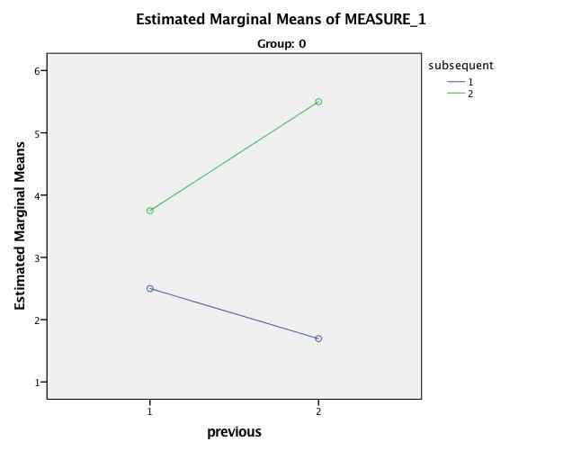

# **Group = 1**

Between-Subjects Factors<sup>a</sup>Between-Subjects Factors, table, 1 levels of column headers and 0 levels of row headers, table with 1 columns and 4 rows

a. Group = 1

Descriptive Statistics<sup>a</sup>Descriptive Statistics, table, 1 levels of column headers and 1 levels of row headers, table with 4 columns and 7 rows

|  | Mean | Std. Deviation | N |
| --- | --- | --- | --- |
| TPT_A | 2.89 | 2.275 | 38 |
| TPC_A | 4.50 | 2.140 | 38 |
| CPT_A | 1.84 | 1.516 | 38 |
| CPC_A | 3.50 | 2.523 | 38 |

a. Group = 1

Multivariate Tests<sup>a,b</sup>Multivariate Tests, table, 1 levels of column headers and 2 levels of row headers, table with 8 columns and 17 rows

| Effect |  | Value | F | Hypothesis df | Error df | Sig. | Partial Eta Squared |
| --- | --- | --- | --- | --- | --- | --- | --- |
| previous | Pillai's Trace | .138 | 5.913<sup>c</sup> | 1.000 | 37.000 | .020 | .138 |
|  | Wilks' Lambda | .862 | 5.913<sup>c</sup> | 1.000 | 37.000 | .020 | .138 |
|  | Hotelling's Trace | .160 | 5.913<sup>c</sup> | 1.000 | 37.000 | .020 | .138 |
|  | Roy's Largest Root | .160 | 5.913<sup>c</sup> | 1.000 | 37.000 | .020 | .138 |
| subsequent | Pillai's Trace | .374 | 22.102<sup>c</sup> | 1.000 | 37.000 | .000 | .374 |
|  | Wilks' Lambda | .626 | 22.102<sup>c</sup> | 1.000 | 37.000 | .000 | .374 |
|  | Hotelling's Trace | .597 | 22.102<sup>c</sup> | 1.000 | 37.000 | .000 | .374 |
|  | Roy's Largest Root | .597 | 22.102<sup>c</sup> | 1.000 | 37.000 | .000 | .374 |
| previous * subsequent | Pillai's Trace | .000 | .008<sup>c</sup> | 1.000 | 37.000 | .930 | .000 |
|  | Wilks' Lambda | 1.000 | .008<sup>c</sup> | 1.000 | 37.000 | .930 | .000 |
|  | Hotelling's Trace | .000 | .008<sup>c</sup> | 1.000 | 37.000 | .930 | .000 |
|  | Roy's Largest Root | .000 | .008<sup>c</sup> | 1.000 | 37.000 | .930 | .000 |

a. Group = 1  
b. Design: Intercept Within Subjects Design: previous + subsequent + previous * subsequent  
c. Exact statistic

Mauchly's Test of Sphericity<sup>a,b</sup>Mauchly's Test of Sphericity, table, Measure, MEASURE_1, 1 layers, 2 levels of column headers and 1 levels of row headers, table with 8 columns and 11 rows

| MEASURE_1 |  |  |  |  |  |  |  |
| --- | --- | --- | --- | --- | --- | --- | --- |
| Within Subjects Effect | Mauchly's W | Approx. Chi-Square | df | Sig. | Epsilon<sup>c</sup> |  |  |
|  |  |  |  |  | Greenhouse-Geisser | Huynh-Feldt | Lower-bound |
| previous | 1.000 | .000 | 0 | . | 1.000 | 1.000 | 1.000 |
| subsequent | 1.000 | .000 | 0 | . | 1.000 | 1.000 | 1.000 |
| previous * subsequent | 1.000 | .000 | 0 | . | 1.000 | 1.000 | 1.000 |

Tests the null hypothesis that the error covariance matrix of the orthonormalized transformed dependent variables is proportional to an identity matrix.  
a. Group = 1  
b. Design: Intercept Within Subjects Design: previous + subsequent + previous * subsequent  
c. May be used to adjust the degrees of freedom for the averaged tests of significance. Corrected tests are displayed in the Tests of Within-Subjects Effects table.

Tests of Within-Subjects Effects<sup>a</sup>Tests of Within-Subjects Effects, table, Measure, MEASURE_1, 1 layers, 1 levels of column headers and 2 levels of row headers, table with 8 columns and 28 rows

| MEASURE_1 |  |  |  |  |  |  |  |
| --- | --- | --- | --- | --- | --- | --- | --- |
| Source |  | Type III Sum of Squares | df | Mean Square | F | Sig. | Partial Eta Squared |
| previous | Sphericity Assumed | 40.026 | 1 | 40.026 | 5.913 | .020 | .138 |
|  | Greenhouse-Geisser | 40.026 | 1.000 | 40.026 | 5.913 | .020 | .138 |
|  | Huynh-Feldt | 40.026 | 1.000 | 40.026 | 5.913 | .020 | .138 |
|  | Lower-bound | 40.026 | 1.000 | 40.026 | 5.913 | .020 | .138 |
| Error(previous) | Sphericity Assumed | 250.474 | 37 | 6.770 |  |  |  |
|  | Greenhouse-Geisser | 250.474 | 37.000 | 6.770 |  |  |  |
|  | Huynh-Feldt | 250.474 | 37.000 | 6.770 |  |  |  |
|  | Lower-bound | 250.474 | 37.000 | 6.770 |  |  |  |
| subsequent | Sphericity Assumed | 101.158 | 1 | 101.158 | 22.102 | .000 | .374 |
|  | Greenhouse-Geisser | 101.158 | 1.000 | 101.158 | 22.102 | .000 | .374 |
|  | Huynh-Feldt | 101.158 | 1.000 | 101.158 | 22.102 | .000 | .374 |
|  | Lower-bound | 101.158 | 1.000 | 101.158 | 22.102 | .000 | .374 |
| Error(subsequent) | Sphericity Assumed | 169.342 | 37 | 4.577 |  |  |  |
|  | Greenhouse-Geisser | 169.342 | 37.000 | 4.577 |  |  |  |
|  | Huynh-Feldt | 169.342 | 37.000 | 4.577 |  |  |  |
|  | Lower-bound | 169.342 | 37.000 | 4.577 |  |  |  |
| previous * subsequent | Sphericity Assumed | .026 | 1 | .026 | .008 | .930 | .000 |
|  | Greenhouse-Geisser | .026 | 1.000 | .026 | .008 | .930 | .000 |
|  | Huynh-Feldt | .026 | 1.000 | .026 | .008 | .930 | .000 |
|  | Lower-bound | .026 | 1.000 | .026 | .008 | .930 | .000 |
| Error(previous*subsequent) | Sphericity Assumed | 123.474 | 37 | 3.337 |  |  |  |
|  | Greenhouse-Geisser | 123.474 | 37.000 | 3.337 |  |  |  |
|  | Huynh-Feldt | 123.474 | 37.000 | 3.337 |  |  |  |
|  | Lower-bound | 123.474 | 37.000 | 3.337 |  |  |  |

a. Group = 1

Tests of Within-Subjects Contrasts<sup>a</sup>Tests of Within-Subjects Contrasts, table, Measure, MEASURE_1, 1 layers, 1 levels of column headers and 3 levels of row headers, table with 9 columns and 10 rows

| MEASURE_1 |  |  |  |  |  |  |  |  |
| --- | --- | --- | --- | --- | --- | --- | --- | --- |
| Source | previous | subsequent | Type III Sum of Squares | df | Mean Square | F | Sig. | Partial Eta Squared |
| previous | Linear |  | 40.026 | 1 | 40.026 | 5.913 | .020 | .138 |
| Error(previous) | Linear |  | 250.474 | 37 | 6.770 |  |  |  |
| subsequent |  | Linear | 101.158 | 1 | 101.158 | 22.102 | .000 | .374 |
| Error(subsequent) |  | Linear | 169.342 | 37 | 4.577 |  |  |  |
| previous * subsequent | Linear | Linear | .026 | 1 | .026 | .008 | .930 | .000 |
| Error(previous*subsequent) | Linear | Linear | 123.474 | 37 | 3.337 |  |  |  |

a. Group = 1

Tests of Between-Subjects Effects<sup>a</sup>Tests of Between-Subjects Effects, table, Measure, MEASURE_1, Transformed Variable, Average, 1 layers, 1 levels of column headers and 1 levels of row headers, table with 7 columns and 7 rows

| MEASURE_1 Average |  |  |  |  |  |  |
| --- | --- | --- | --- | --- | --- | --- |
| Source | Type III Sum of Squares | df | Mean Square | F | Sig. | Partial Eta Squared |
| Intercept | 1541.158 | 1 | 1541.158 | 412.187 | .000 | .918 |
| Error | 138.342 | 37 | 3.739 |  |  |  |

a. Group = 1

# **Profile Plots**

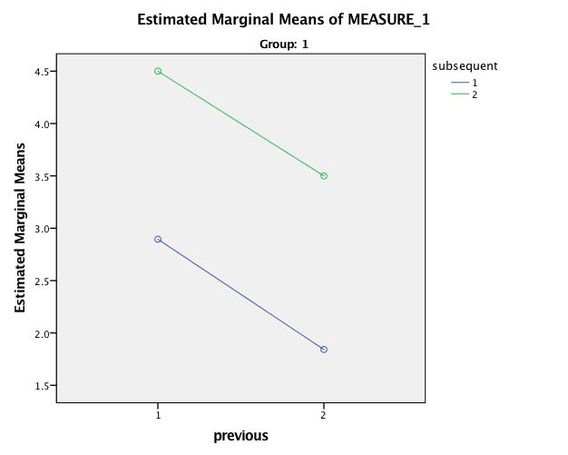